# Partial regression on the Boston Housing Dataset

Michaletzky Tamás (PMBLWY)

# Abstract

We will do partial least square regression (*plsr*) on the commonly-used Boston dataset in language R using the package `pls`. This method is often used when we build such a linear model where there are relatively few samples but many, possibly correlated predictors.[^1] In such cases it is well-known that standard multiple regression models could fail.[^2] Our main aim is to predict the median value of Boston houses with as less predictors as possible using *plsr*.

# Preparation

```r
rm(list = ls())

options(digits = 4)
```

```r
#install.packages("pls")
library(pls)
```

```r
#install.packages("MASS")
library(MASS)

#install.packages("corrplot")
library(corrplot)
```

After cleaning memory from junk and installing packages needed we should attach the Boston data set.

```r
data(Boston)
attach(Boston)

?Boston
```

The dataset contains 506 rows and 14 columns (13 predictors and 1 target value `medv`).

```r
head(Boston)
```

|  | crim | zn | indus | chas | nox | rm | age | dis | rad | tax | ptratio | black | lstat | medv |
| --- | --- | --- | --- | --- | --- | --- | --- | --- | --- | --- | --- | --- | --- | --- |
| 1 | 0.00632 | 18 | 2.31 | 0 | 0.538 | 6.575 | 65.2 | 4.090 | 1 | 296 | 15.3 | 396.9 | 4.98 | 24.0 |
| 2 | 0.02731 | 0 | 7.07 | 0 | 0.469 | 6.421 | 78.9 | 4.967 | 2 | 242 | 17.8 | 396.9 | 9.14 | 21.6 |
| 3 | 0.02729 | 0 | 7.07 | 0 | 0.469 | 7.185 | 61.1 | 4.967 | 2 | 242 | 17.8 | 392.8 | 4.03 | 34.7 |
| 4 | 0.03237 | 0 | 2.18 | 0 | 0.458 | 6.998 | 45.8 | 6.062 | 3 | 222 | 18.7 | 394.6 | 2.94 | 33.4 |
| 5 | 0.06905 | 0 | 2.18 | 0 | 0.458 | 7.147 | 54.2 | 6.062 | 3 | 222 | 18.7 | 396.9 | 5.33 | 36.2 |
| 6 | 0.02985 | 0 | 2.18 | 0 | 0.458 | 6.430 | 58.7 | 6.062 | 3 | 222 | 18.7 | 394.1 | 5.21 | 28.7 |

We can get an overview of the dataset or from a certain variable:

```r
summary(medv)
```

```
##    Min. 1st Qu.  Median    Mean 3rd Qu.    Max.
##     5.0    17.0    21.2    22.5    25.0    50.0
```

Plotting the correlation table it is seen that `lstat` and `rm` are significantly correlated (negatively and positively, respectively) with target value `medv`, but one could also observe that there are other significant correlations between predictors, for example `indus`, `dis` and `tax` are highly correlated with the others, among many as well. It is also foreshadowed that the dummy variable `chas` could be negligable.

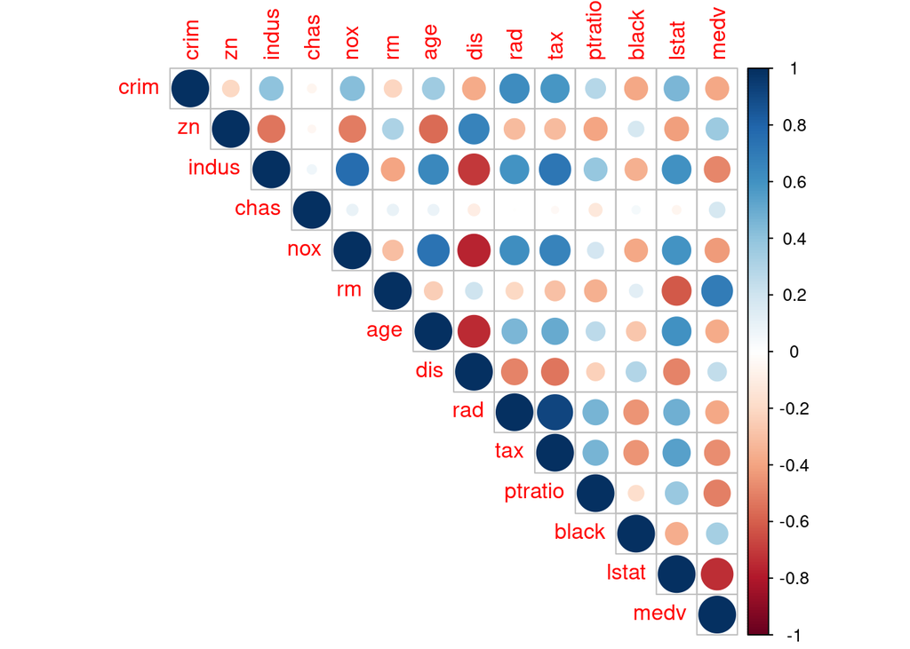

```r
corrplot(cor(Boston), type="upper")
```

Given these circumstances and the relative few samples against the number of predictors it sounds a good idea to use *plsr*.

Before building a model one should split the data randomly into training and testing part. We will use the standard `75%` splitting.

```r
sample_size <- floor(0.75*nrow(Boston))
train_indicies <- sample(seq_len(nrow(Boston)), size=sample_size)

train <- Boston[train_indicies, ]
test <- Boston[-train_indicies, ]
```

We should also check if there is any missing values but there is no.

```r
any(is.na(Boston))
```

```
## [1] FALSE
```

We are now ready to build our models.

# Build the model

## First model

At first let’s see what one could got using only the significantly correlated predictors. This is what we will try to improve.

```r
M0 <- plsr(medv ~ lstat+rm, data = train)
summary(M0)
```

```
## Data:    X dimension: 379 2
##  Y dimension: 379 1
## Fit method: kernelpls
## Number of components considered: 2
## TRAINING: % variance explained
##       1 comps  2 comps
## X       99.41   100.00
## medv    53.62    64.33
```

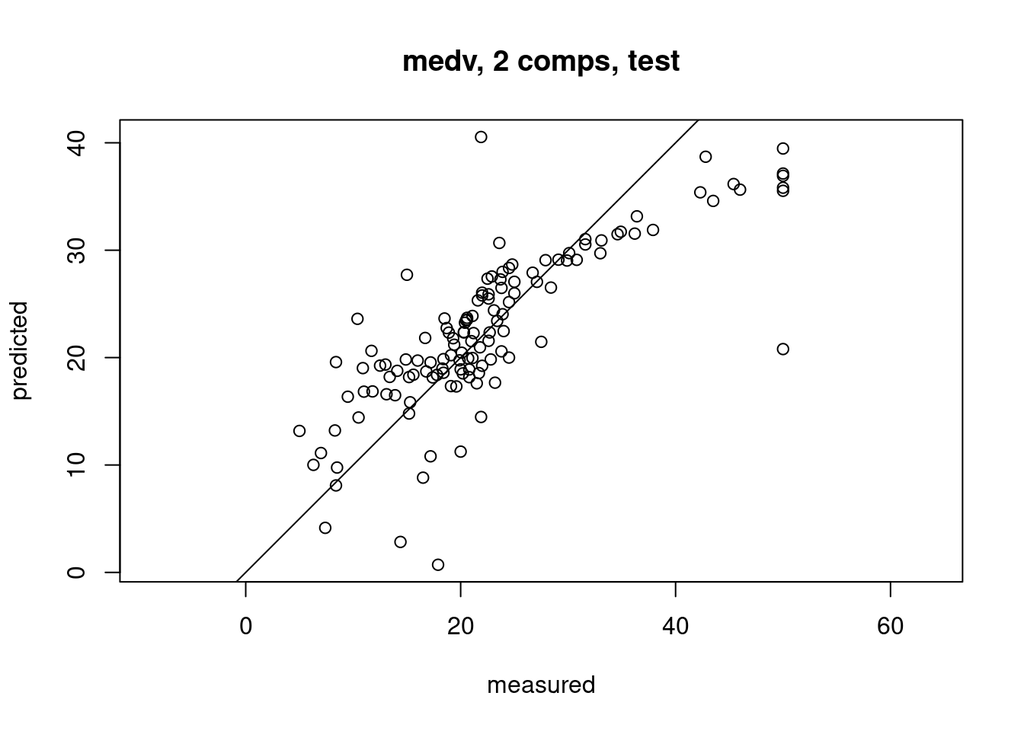

```r
plot(M0, "prediction", newdata=test, line=TRUE, asp=1)
```

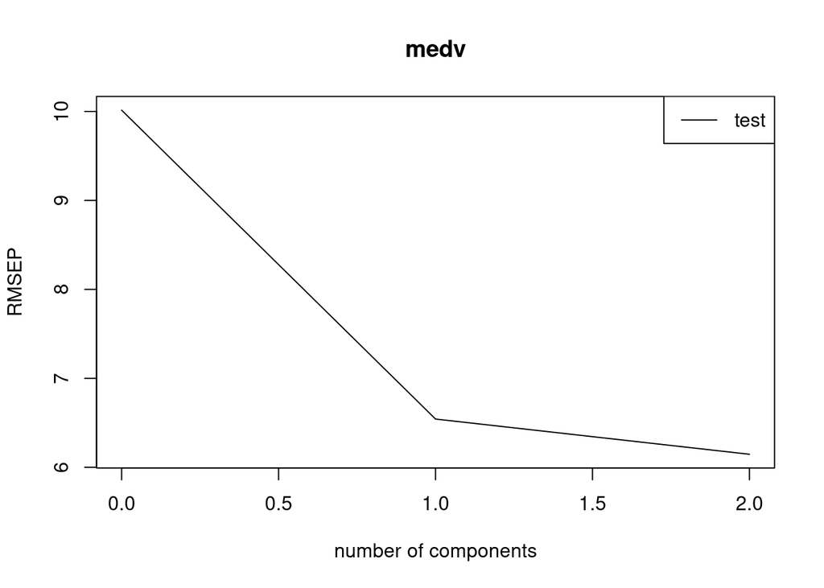

```r
plot(RMSEP(M0, newdata=test), legendpos="topright")
```

## *PLSR* model

### Dimension reduction

For the *plsr* model we should use all the predictors. For validation we will use `"LOO"`, *leave-one-out* cross-validated predictions.

```r
M1 <- plsr(medv ~ crim + zn + indus + chas + nox + rm + age + dis + rad + tax + ptratio + black + lstat, data = train, validation="LOO")
summary(M1)
```

```
## Data:    X dimension: 379 13
##  Y dimension: 379 1
## Fit method: kernelpls
## Number of components considered: 13
##
## VALIDATION: RMSEP
## Cross-validated using 379 leave-one-out segments.
##        (Intercept)  1 comps  2 comps  3 comps  4 comps  5 comps  6 comps
## CV           8.918    7.801    7.669    7.415    6.451    5.657    5.423
## adjCV        8.918    7.801    7.669    7.415    6.451    5.657    5.422
##        7 comps  8 comps  9 comps  10 comps  11 comps  12 comps  13 comps
## CV        5.17    5.011    4.926     4.786     4.642     4.625     4.578
## adjCV     5.17    5.011    4.926     4.786     4.641     4.625     4.577
##
## TRAINING: % variance explained
##       1 comps  2 comps  3 comps  4 comps  5 comps  6 comps  7 comps  8 comps
## X       79.41    94.10    98.97    99.42    99.84    99.90    99.94    99.97
## medv    23.97    26.85    32.01    49.61    61.44    65.18    68.64    70.43
##       9 comps  10 comps  11 comps  12 comps  13 comps
## X       99.99    100.00    100.00    100.00    100.00
## medv    71.41     73.08     75.13     75.56     76.15
```

At first let’s see wether there is a reason not to use linear predictions.

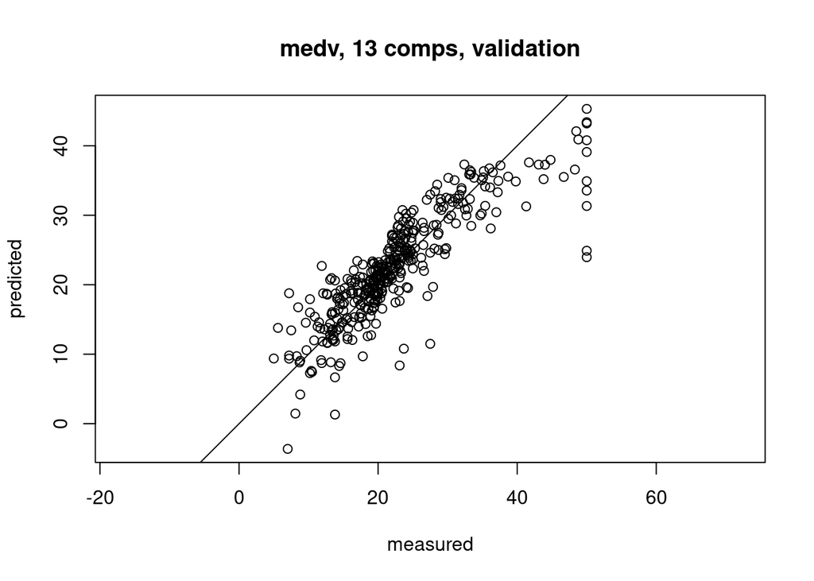

```r
plot(M1, asp = 1, line = TRUE)
```

This seems fine, although the values on the right hand side looks fake at first glance, therefore may need to outline if the model got bad from them.

So now let’s reduce the number of components. For this we shall plot the *RMSEP*, the root mean squared error of prediction, indicating how many components we should leave.

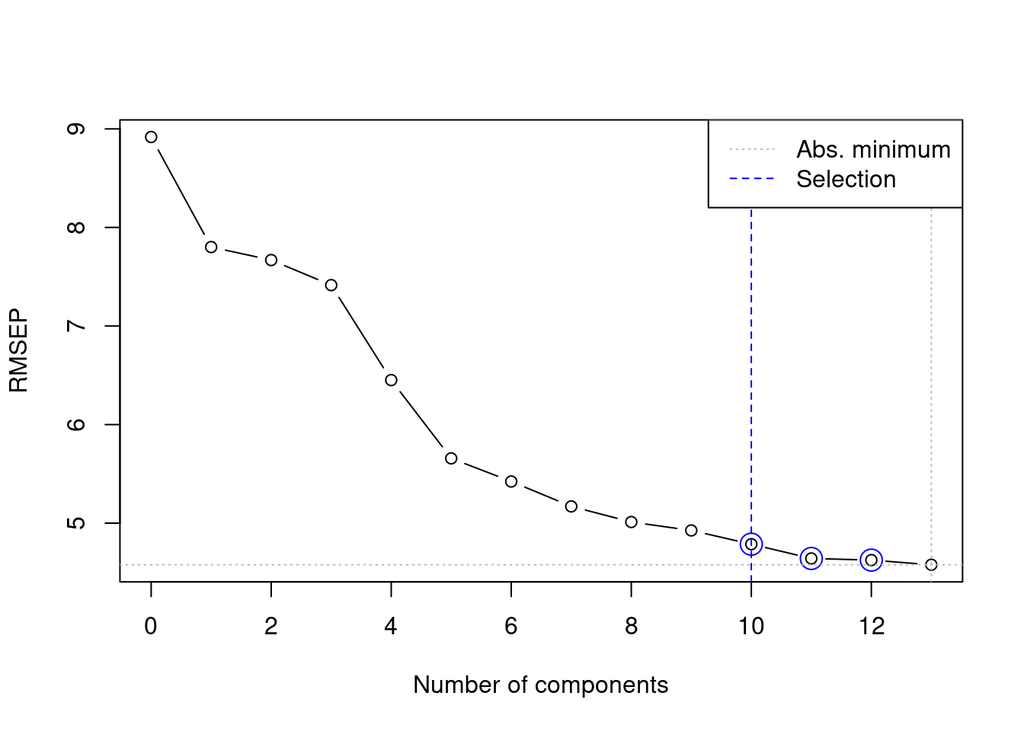

```r
M1.ncomp <- selectNcomp(M1, method = "randomization", plot=TRUE)
```

```r
M <- update(M1, ncomp=M1.ncomp)
```

This premises that `M1.ncomp` components will be enough for model `M`. That is, with this splitting is 10.[^3]

### Checking for anomalies

Looking at the correlation and score plot of loadings we can say that there is no clear indication of grouping or outlying predictors.

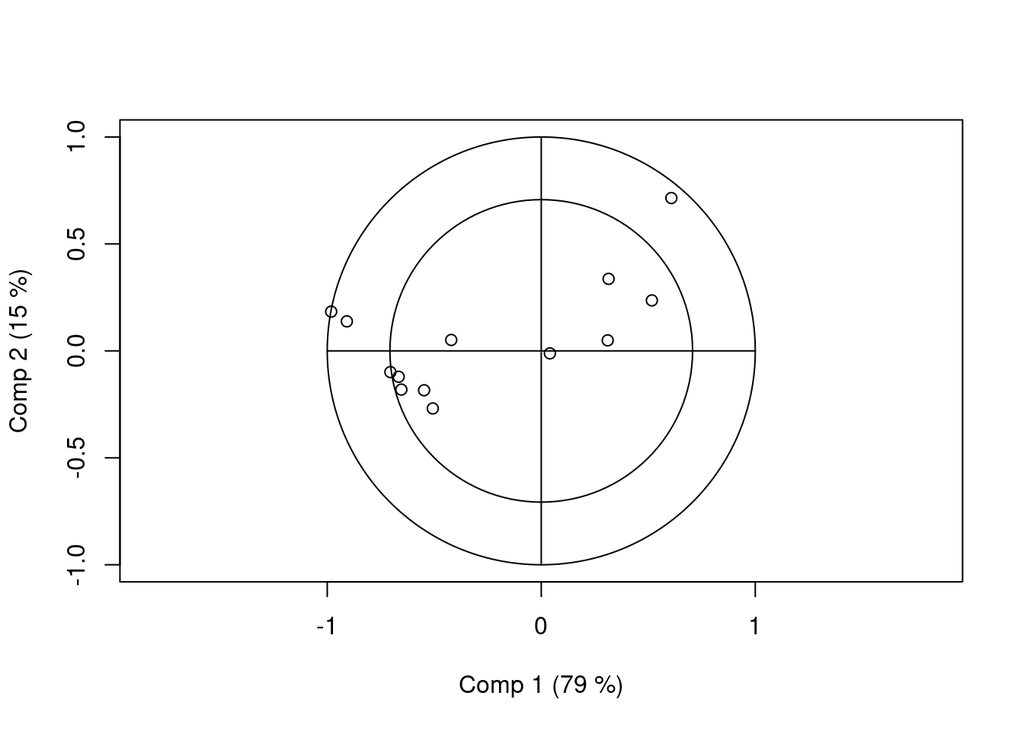

```r
plot(M, "correlation")
```

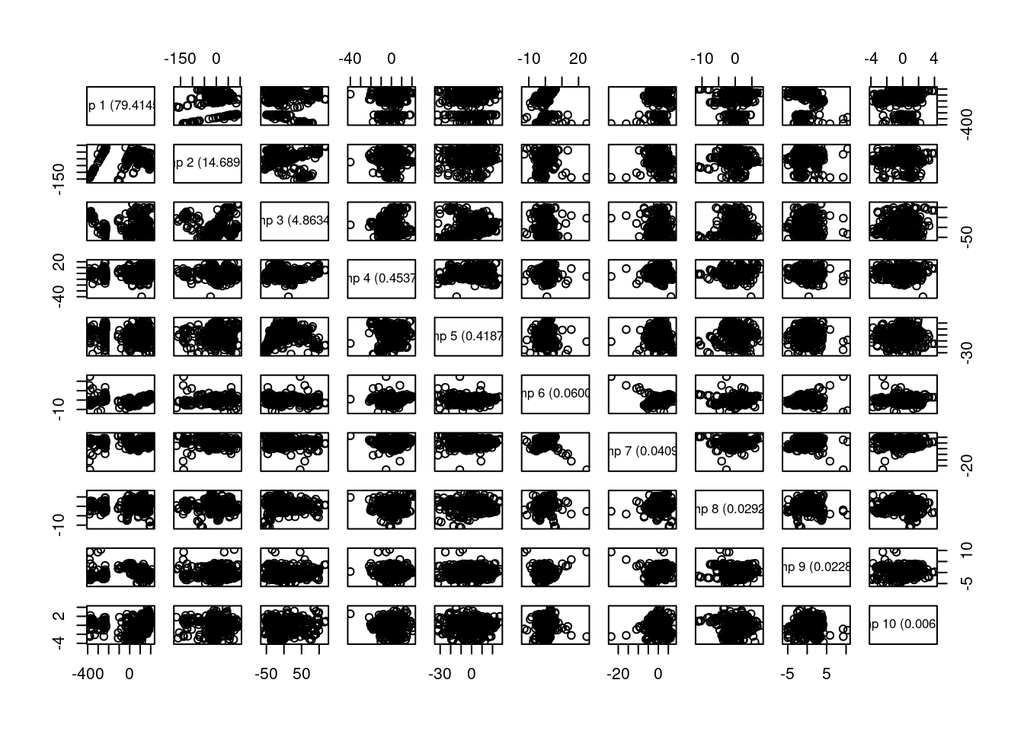

```r
plot(M, plottype = "scores", comps=1:M1.ncomp)
```

Plotting the coefficients it is also seen that while some seems to be close to one-another the last used components is needed, or at least adds a significant change to the model.

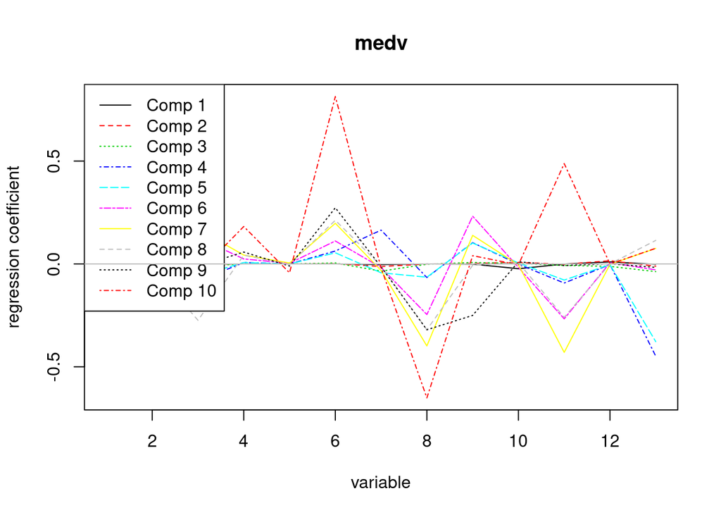

```r
plot(M, "coefficients", comps=1:M1.ncomp, legendpos="topleft")
```

### Predictions and evaluating the model

As there is no indication for the model to fail trivially we should see the results on the test dataset.

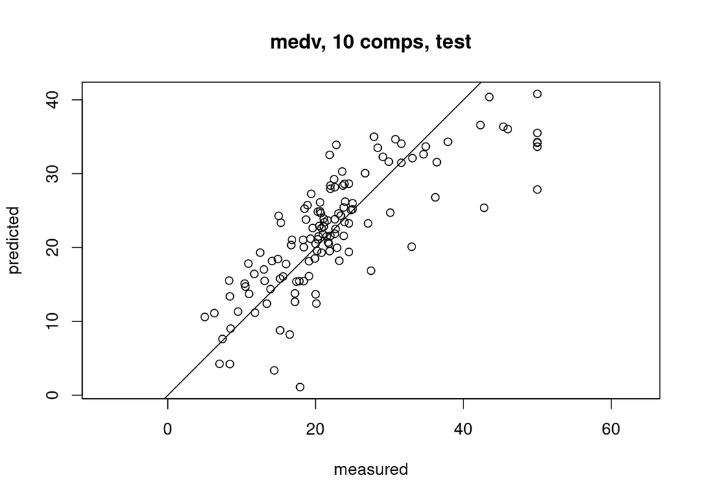

```r
plot(M, ncomp = M1.ncomp, newdata=test, asp = 1, line = TRUE)
```

Plotting the predictions on the `test` dataset one shall say that the model looks fine.

Also the *RMSEP* and explained variances looks promising.

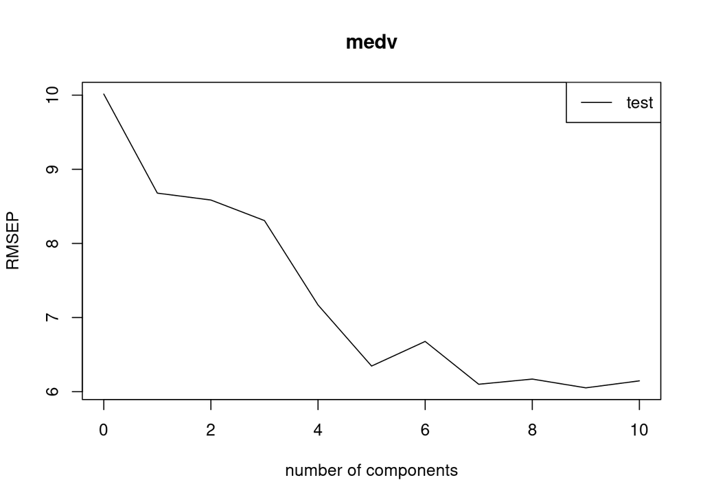

```r
M.rmsep <- RMSEP(M, newdata=test)
plot(M.rmsep, legendpos = "topright")
```

```r
explvar(M1)
```

```
##    Comp 1    Comp 2    Comp 3    Comp 4    Comp 5    Comp 6    Comp 7    Comp 8
## 7.941e+01 1.469e+01 4.863e+00 4.537e-01 4.187e-01 5.995e-02 4.090e-02 2.920e-02
##    Comp 9   Comp 10   Comp 11   Comp 12   Comp 13
## 2.276e-02 6.701e-03 9.742e-04 1.627e-04 8.887e-06
```

```r
sum(explvar(M))
```

```
## [1] 100
```

# Other models

## *PCR*

*PCR* stands for principal component regression. Due to the authors of the `pls` package it is usual that *plsr* models use less components than *pcr* models, but not yet proven nor been falsified.[^4] This time we only need one more component.

```r
M.pcr <- pcr(medv ~ crim + zn + indus + chas + nox + rm + age + dis + rad + tax + ptratio + black + lstat, data = train, validation="LOO")
summary(M.pcr)
```

```
## Data:    X dimension: 379 13
##  Y dimension: 379 1
## Fit method: svdpc
## Number of components considered: 13
##
## VALIDATION: RMSEP
## Cross-validated using 379 leave-one-out segments.
##        (Intercept)  1 comps  2 comps  3 comps  4 comps  5 comps  6 comps
## CV           8.918    7.829    7.809    7.575    7.559    6.987    5.926
## adjCV        8.918    7.829    7.809    7.575    7.559    6.987    5.926
##        7 comps  8 comps  9 comps  10 comps  11 comps  12 comps  13 comps
## CV       5.848    5.731     5.27     4.985     4.668     4.636     4.578
## adjCV    5.848    5.731     5.27     4.985     4.668     4.636     4.577
##
## TRAINING: % variance explained
##       1 comps  2 comps  3 comps  4 comps  5 comps  6 comps  7 comps  8 comps
## X       79.51    96.72    99.02    99.76    99.85    99.92    99.96    99.99
## medv    23.37    24.01    28.86    29.57    40.34    57.41    59.15    60.80
##       9 comps  10 comps  11 comps  12 comps  13 comps
## X      100.00    100.00    100.00    100.00    100.00
## medv    67.07     70.64     74.69     75.47     76.15
```

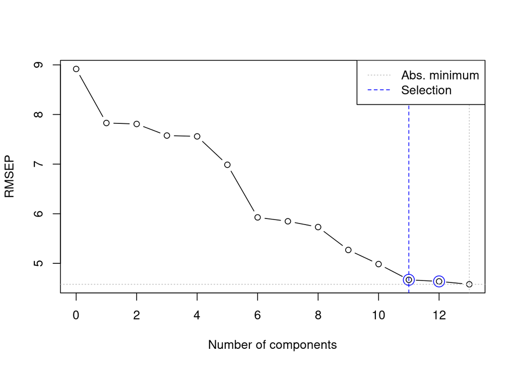

```r
ncomp.pcr <- selectNcomp(M.pcr, method = "randomization", plot=TRUE)
```

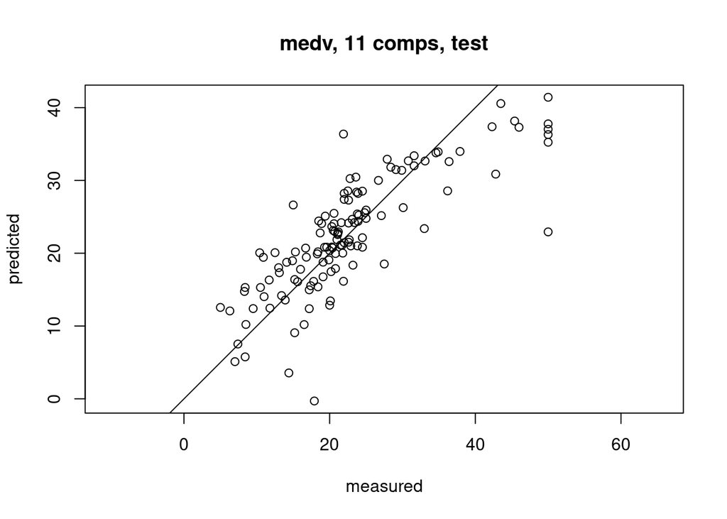

```r
M3 <- update(M.pcr, ncomp=ncomp.pcr)
plot(M3, newdata=test, asp=1, line=TRUE)
```

```r
explvar(M.pcr)
```

```
##    Comp 1    Comp 2    Comp 3    Comp 4    Comp 5    Comp 6    Comp 7    Comp 8
## 7.951e+01 1.722e+01 2.294e+00 7.409e-01 9.140e-02 7.179e-02 4.016e-02 2.357e-02
##    Comp 9   Comp 10   Comp 11   Comp 12   Comp 13
## 9.389e-03 3.208e-03 6.218e-04 1.541e-04 8.158e-06
```

```r
sum(explvar(M3))
```

```
## [1] 100
```

## Scaled *plsr* model

We can also lower the number of components needed if one uses scaling on the predictors.

```r
M.sc <- update(M1, scale = TRUE)
summary(M.sc)
```

```
## Data:    X dimension: 379 13
##  Y dimension: 379 1
## Fit method: kernelpls
## Number of components considered: 13
##
## VALIDATION: RMSEP
## Cross-validated using 379 leave-one-out segments.
##        (Intercept)  1 comps  2 comps  3 comps  4 comps  5 comps  6 comps
## CV           8.918    6.338     4.81    4.695    4.647    4.622    4.603
## adjCV        8.918    6.338     4.81    4.695    4.647    4.622    4.603
##        7 comps  8 comps  9 comps  10 comps  11 comps  12 comps  13 comps
## CV        4.58    4.576    4.577     4.576     4.577     4.578     4.578
## adjCV     4.58    4.576    4.577     4.576     4.577     4.578     4.577
##
## TRAINING: % variance explained
##       1 comps  2 comps  3 comps  4 comps  5 comps  6 comps  7 comps  8 comps
## X       45.11    56.03    63.57    70.03    75.81    79.18    82.89    85.60
## medv    50.30    72.60    74.43    75.34    75.79    76.00    76.07    76.14
##       9 comps  10 comps  11 comps  12 comps  13 comps
## X       90.78     94.06     96.71     98.44    100.00
## medv    76.15     76.15     76.15     76.15     76.15
```

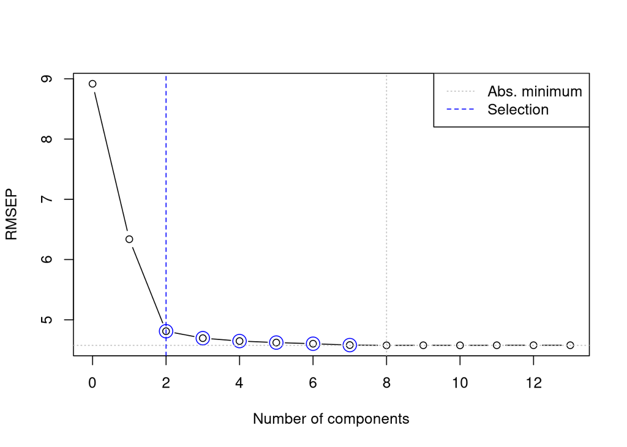

```r
ncomp.scaled <- selectNcomp(M.sc, method = "randomization", plot = TRUE)
```

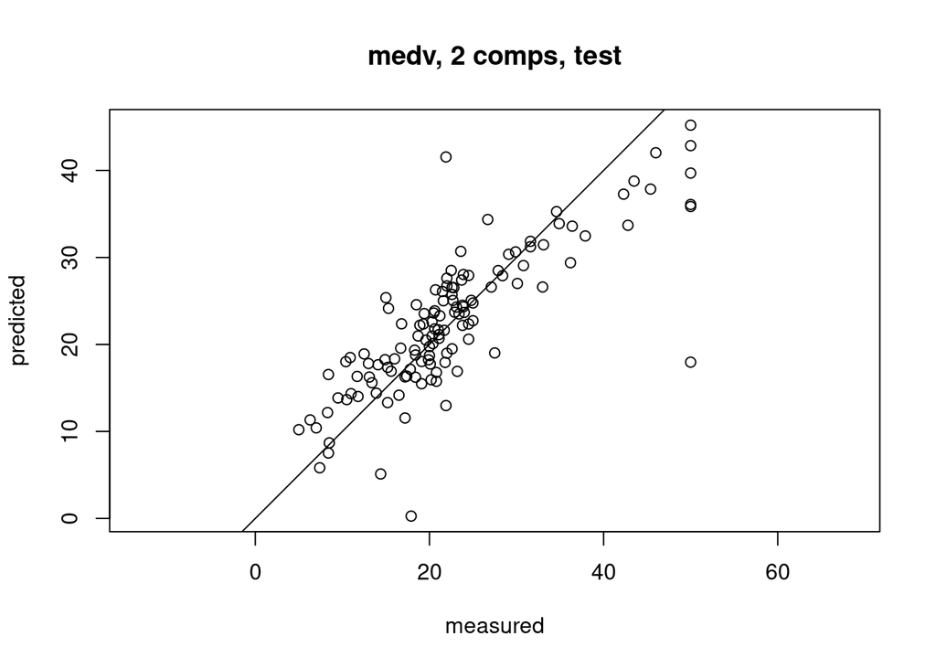

```r
M2 <- update(M.sc, ncomp=ncomp.scaled)
plot(M2, newdata=test, line=TRUE, asp = 1)
```

```r
explvar(M.sc)
```

```
##  Comp 1  Comp 2  Comp 3  Comp 4  Comp 5  Comp 6  Comp 7  Comp 8  Comp 9 Comp 10
##  45.109  10.917   7.547   6.452   5.782   3.377   3.709   2.703   5.186   3.280
## Comp 11 Comp 12 Comp 13
##   2.645   1.736   1.556
```

```r
sum(explvar(M2))
```

```
## [1] 56.03
```

# Comparisons

A barplot on the coefficients on the 3 latter models shows that while the one built with scaling differs a lot the other two are closely the same.

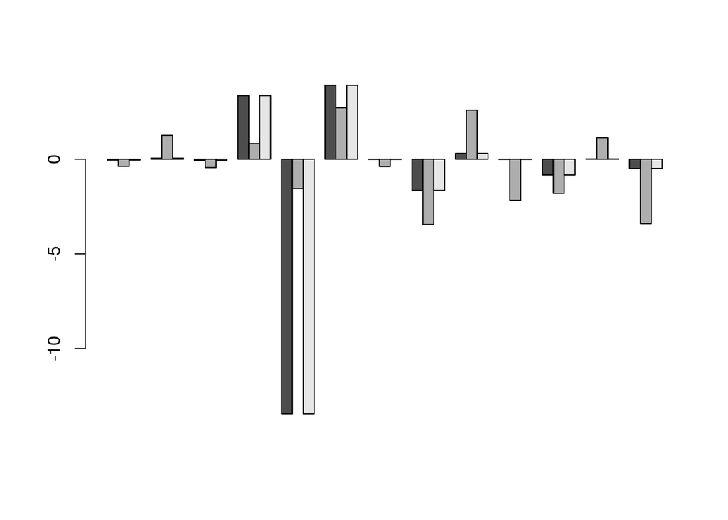

```r
coefs <- matrix(c(coef(M1), coef(M.sc), coef(M.pcr)), ncol = 3)
barplot(t(coefs), beside=TRUE)
```

```r
coefs[,c(1,3)]
```

```
##            [,1]      [,2]
##  [1,]  -0.05195  -0.05195
##  [2,]   0.05438   0.05438
##  [3,]  -0.06640  -0.06640
##  [4,]   3.35612   3.35612
##  [5,] -13.45466 -13.45466
##  [6,]   3.90364   3.90364
##  [7,]  -0.01374  -0.01374
##  [8,]  -1.65182  -1.65182
##  [9,]   0.30527   0.30527
## [10,]  -0.01332  -0.01332
## [11,]  -0.83323  -0.83323
## [12,]   0.01220   0.01220
## [13,]  -0.48812  -0.48812
```

```r
sqrt(sum(coef(M1), -coef(M.pcr))^2/13)
```

```
## [1] 2.463e-15
```

Also comparing the _RMSEP_s reveals that there is a significant difference between the models built with or without scaling.

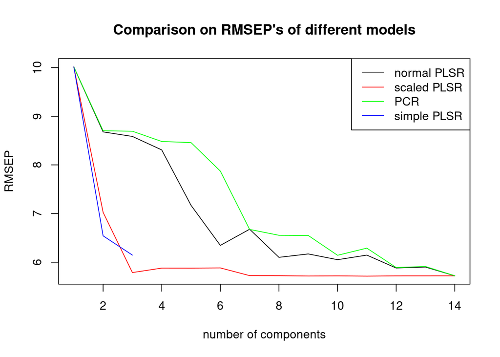

```r
make_rmsep <- function(model){   result <- RMSEP(model, newdata=test)[["val"]]  }

x<-1:14
y1<-make_rmsep(M1)
y2<-make_rmsep(M.sc)
y3<-make_rmsep(M.pcr)
y4<-make_rmsep(M0)

plot(x,y1,type="l", xlab = "number of components", ylab = "RMSEP", main = "Comparison on RMSEP's of different models")
lines(x,y2, type = "l", col="red")
lines(x,y3,type = "l", col="green")
lines(1:3,y4, type="l", col="blue")
legend("topright", legend = c("normal PLSR", "scaled PLSR", "PCR", "simple PLSR"), col = c("black","red", "green", "blue"), lty = 1)
```

Additionally we also have seen that the ovarall explained variance differs as well.

```r
options(digits = 6)
sum(explvar(M))
```

```
## [1] 99.9989
```

```r
sum(explvar(M2))
```

```
## [1] 56.0264
```

```r
sum(explvar(M3))
```

```
## [1] 99.9998
```

# Conclusions

We built in total 4 models based on *plsr* methods. We can conlude that we could build a better model than the trivial first one. We can also conlcude that there was no practical effects for building a model with *pcr*. The remaining two models compete: while having less components for the same amount of *RMSEP* error, the scaled model also explaines less variance on the data than the more components normal model.

Therefore it is now up to further considerations depending our goals to decide which model to go with.

# Appendix: About RMarkdown

[^1]: See section 2 in https://cran.r-project.org/web/packages/pls/vignettes/pls-manual.pdf
[^2]: https://www.wikiwand.com/en/Partial_least_squares_regression
[^3]: It is worth mentioning that with different random splitting one could get 9 components, not 10, as it is here stated. Or at least I could.
[^4]: See section 2.2 in https://cran.r-project.org/web/packages/pls/vignettes/pls-manual.pdf